# Racial Equity Analysis with HMIS Data

Luke Saunders

## Importing The Data

There are two sheets within the xlsx file that we need to import and combine into a single dataframe.

```r
# accessing all the sheets
sheet = excel_sheets("Analyst Sr Assignment  - Dataset.xlsx")

# applying sheet names to dataframe names
Demographics <- read_excel("Analyst Sr Assignment  - Dataset.xlsx", sheet = "Client Demographics")

Entry_Exit <- read_excel("Analyst Sr Assignment  - Dataset.xlsx", sheet = "Entry Exit")
```

### Cleaning Data Before Merging

There are a few values that are equal to NA as specified by the codebook. This code will change those values.

```r
Demographics_cleaned <- Demographics %>%
   mutate(across(where(is.character), ~na_if(., "Client doesn't know")))

Demographics_cleaned <- Demographics_cleaned %>%
   mutate(across(where(is.character), ~na_if(., "Client refused")))

Demographics_cleaned <- Demographics_cleaned %>%
   mutate(across(where(is.character), ~na_if(., "Data not collected")))
```

```r
# merge sheets

hmis <- merge(Demographics_cleaned, Entry_Exit, by=c("Client ID"))
```

## Create New Variables

There are variables we need to create to make things a bit easier. I will create an age variable calculated from DOB and a race and ethnicity variable using New Race and Race Additional.

### Age

```r
age = function(from, to) {
  from_lt = as.POSIXlt(from)
  to_lt = as.POSIXlt(to)

  age = to_lt$year - from_lt$year

  ifelse(to_lt$mon < from_lt$mon |
         (to_lt$mon == from_lt$mon & to_lt$mday < from_lt$mday),
         age - 1, age)
}

hmis$age <- age(hmis$`Date of Birth`, "2019-06-30 00:00:00")
```

### Race/Ethnicity

```r
# multiracial

hmis <- hmis %>% mutate(Multiracial = ifelse(`Race-Additional` == "", 0, 1))
hmis$Multiracial[is.na(hmis$Multiracial)] <- 0

## ethnicity

hmis <- hmis %>%
  mutate(Hispanic = ifelse(`Ethnicity` == "Non-Hispanic/Non-Latino", 0, 1))

### create race/ethnicity variable

hmis <- hmis %>%
  mutate(RaceEthnicity = case_when(Multiracial == 1 & Hispanic == 0 ~ "Multiracial (Non-Hispanic)",
                                   Multiracial == 1 & Hispanic == 1 ~ "Multiracial (Hispanic)",
                                   `New Race` == "White" & Hispanic == 0 ~ "White (Non-Hispanic)",
                                   `New Race` == "White" & Hispanic == 1 ~ "White (Hispanic)",
                                   `New Race` == "Black, African American, or African" & Hispanic == 0 ~ "Black, African American, or African (Non-Hispanic)",
                                   `New Race` == "Black, African American, or African" & Hispanic == 1 ~ "Black, African American, or African (Hispanic)",
                                   `New Race` == "Asian or Asian American" & Hispanic == 0 ~ "Asian or Asian American (Non-Hispanic)",
                                   `New Race` == "Asian or Asian American" & Hispanic == 1 ~ "Asian or Asian American (Hispanic)",
                                   `New Race` == "Native Hawaiian or Pacific Islander" & Hispanic == 0 ~ "Native Hawaiian or Pacific Islander (Non-Hispanic)",
                                   `New Race` == "Native Hawaiian or Pacific Islander" & Hispanic == 1 ~ "Native Hawaiian or Pacific Islander (Hispanic)",
                                   `New Race` == "American Indian, Alaska Native, or Indigenous" & Hispanic == 0 ~ "American Indian, Alaska Native, or Indigenous (Non-Hispanic)",
                                   `New Race` == "American Indian, Alaska Native, or Indigenous" & Hispanic == 1 ~ "American Indian, Alaska Native, or Indigenous (Hispanic)"))
```

### Month/Year

We want to see program effectiveness over the FY. We need to create a Month/Year variable here.

```r
# Exit date to M-Y
hmis$`Exit Date` <- as.POSIXct(hmis$`Exit Date`, tz = "UTC")
hmis$`Exit Date` <- as.Date.POSIXct(hmis$`Exit Date`, tz = "UTC")

hmis$Month_Yr <- strptime(as.Date(hmis$`Exit Date`), "%Y-%m-%d")
hmis$Month_Yr <- format(hmis$Month_Yr, "%Y-%m")
```

## Validating The Data

```r
# data validation

## rules
v <- validator("Age in range" = age >= 0 & age <= 120
               ,"Exit Destination Missing" = !is.na(`Exit Destination`)
               ,"Exit Reason Missing" = !is.na(`Exit Reason`)
               ,"Client ID Unique" = is_unique(`Client ID`)
               ,"Client ID Missing" = !is.na(`Client ID`)
               ,"Race/Ethnicity Missing" = !is.na(RaceEthnicity)
               ,"Gender Missing" = !is.na(`Gender`)
               ,"Valid Entry/Exit Date" = `Entry Date` <= "2019-07-01 00:00:00")

# table of pass/fails

cf <- confront(hmis, v)
summary(cf)
```

| name | items | passes | fails | nNA | error | warning | expression |
| --- | --- | --- | --- | --- | --- | --- | --- |
| Age.in.range | 98185 | 96600 | 0 | 1585 | FALSE | FALSE | age - 0 >= -1e-08 & age - 120 <= 1e-08 |
| Exit.Destination.Missing | 98185 | 90568 | 7617 | 0 | FALSE | FALSE | !is.na(`Exit Destination`) |
| Exit.Reason.Missing | 98185 | 90150 | 8035 | 0 | FALSE | FALSE | !is.na(`Exit Reason`) |
| Client.ID.Unique | 98185 | 26777 | 71408 | 0 | FALSE | FALSE | is_unique(`Client ID`) |
| Client.ID.Missing | 98185 | 98185 | 0 | 0 | FALSE | FALSE | !is.na(`Client ID`) |
| Race.Ethnicity.Missing | 98185 | 88291 | 9894 | 0 | FALSE | FALSE | !is.na(RaceEthnicity) |
| Gender.Missing | 98185 | 96091 | 2094 | 0 | FALSE | FALSE | !is.na(Gender) |
| Valid.Entry.Exit.Date | 98185 | 98185 | 0 | 0 | FALSE | FALSE | `Entry Date` <= "2019-07-01 00:00:00" |

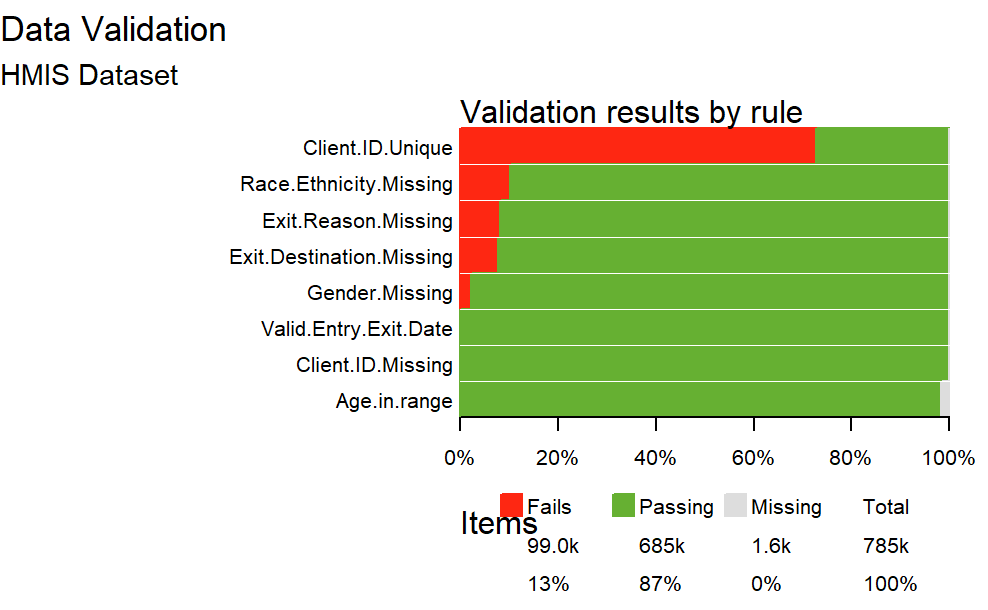

```r
# plot output

as.ggplot(~plot(cf)) +
  labs(title ="Data Validation", subtitle = "HMIS Dataset")
```

It looks like the data is fairly accurate. There are some missing values/blank fields, but some fields are not required to be entered in the HMIS data collection. Everything seems to be within normal ranges.

Finally, we will create a new CSV file from our final dataframe to use in Power BI.

```r
write.csv(hmis, file = "HMIS_Cleaned.csv")
```

## Visualizing Data Using Power BI

### Demographics

First, we need to see if there are any disparities in those receiving homeless assistance compared to the racial makeup of the general population in Multnomah County.

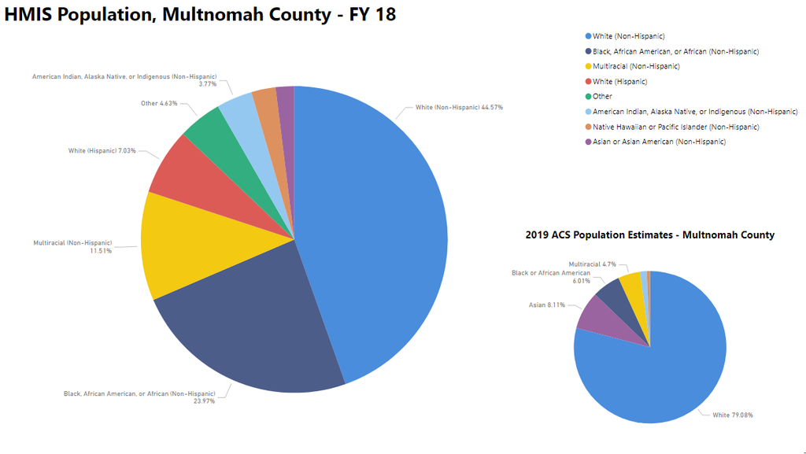

### Exit Outcomes

Next, we will look at how many people completed their respective housing program by month in FY 2018.

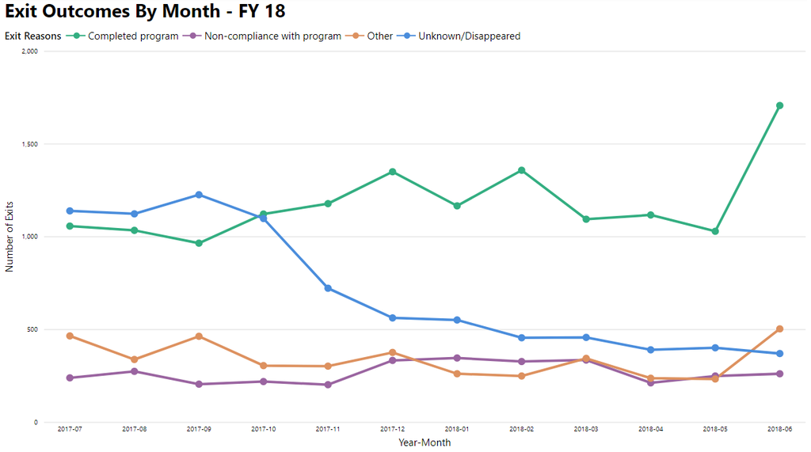

### Exit Destinations

We have seen that the amount of people who completed their programs increased, but where do they end up? For instance, are there any racial disparities in who achieves permanent housing?

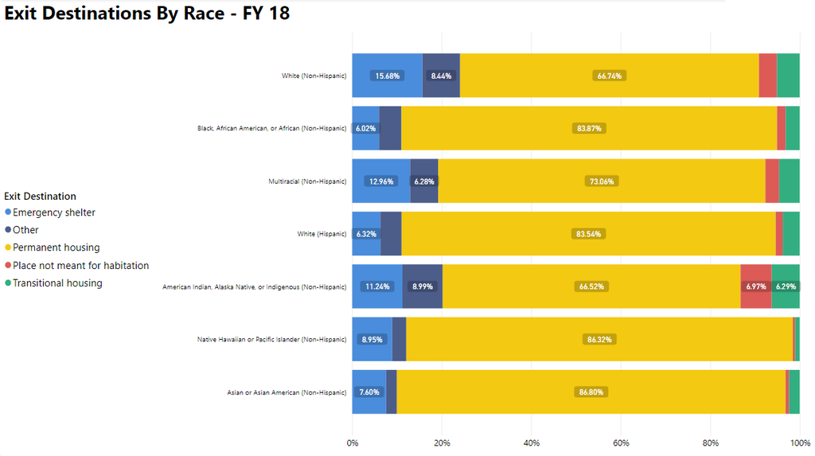

In this visual, we can see that most clients enter emergency shelter or permanent housing. However, American Indians, Alaska Native, or Indigenous people have the lowest rates of achieving permanent housing, while also having the highest rate of places not meant for habitation.

### Stability On Exit

Of all clients, who achieves permanent housing and does not return (i.e., only one entry in the HMIS dataset)?

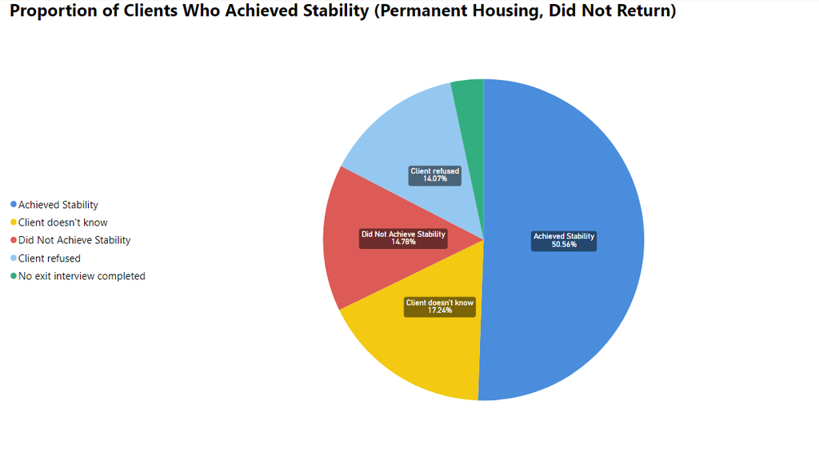

About half of all clients achieve stability, while the other half return at some point during FY 18 or their outcomes are unknown.

### Stability On Exit - By Race

Now that we know that half of clients achieve stability on exit, what does the breakdown by race look like?

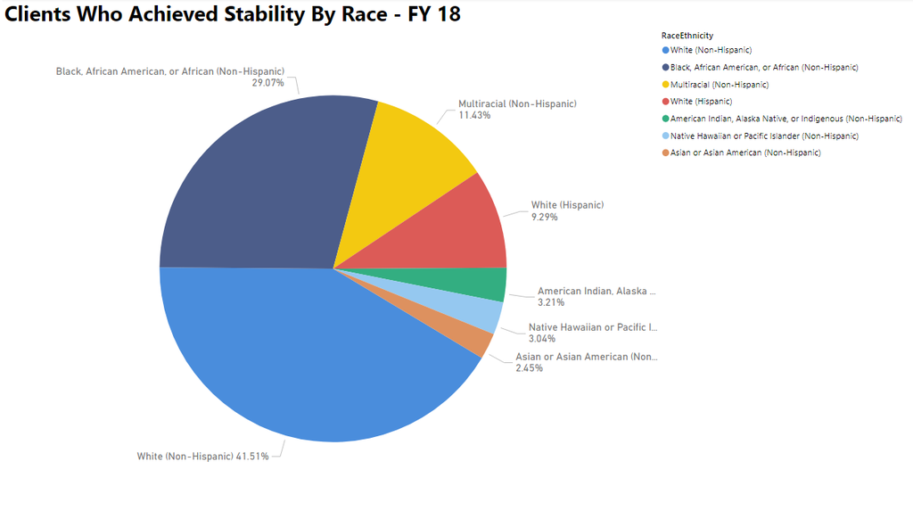

## Hierarchical Logistic Regression

Finally, we can statistically investigate if there are certain predictors that significantly influence a dichotomous outcome (i.e., achieving stability).

```r
# only include distinct cases

hmis_model <- hmis %>%
  distinct_at(vars(`Client ID`), .keep_all = TRUE)

# create variable for stability (0 = not stable or 1 = stable)

hmis_model <- hmis_model %>%
  mutate(stable = ifelse(`Exit Reason` == "Completed program" & `Exit Destination` == "Permanent housing", 1, 0))

# only use complete cases

hmis_model <- na.omit(hmis_model)

# change variables to factor
hmis_model$RaceEthnicity <- factor(hmis_model$RaceEthnicity)
hmis_model$`Gender` <- factor(hmis_model$`Gender`)
hmis_model$`Disabling Condition` <- factor(hmis_model$`Disabling Condition`)
hmis_model$`Veteran Status` <- factor(hmis_model$`Veteran Status`)

# create model

model1 <- glm(stable ~ RaceEthnicity + `Gender` + `Disabling Condition` + age + `Veteran Status`, family = "binomial", hmis_model)
```

### Results Table

|  | *Dependent variable:* |
| --- | --- |
|  | stable |
| RaceEthnicityMultiracial (Non-Hispanic) | 0.135 |
|  | (0.151) |
| GenderMale | -0.192 |
|  | (0.126) |
| GenderTrans Female (MTF or Male to Female) | 0.302 |
|  | (1.159) |
| GenderTrans Male (FTM or Female to Male) | -0.808 |
|  | (1.419) |
| `Disabling Condition`Yes | -0.079 |
|  | (0.155) |
| age | 0.0005 |
|  | (0.005) |
| `Veteran Status`Yes | 0.182 |
|  | (0.287) |
| Constant | 0.708*** |
|  | (0.157) |
| Observations | 1,239 |
| Log Likelihood | -779.840 |
| Akaike Inf. Crit. | 1,575.679 |
| *Note:* | p<0.1; p<0.05; p<0.01 |

There are no significant predictors of achieving stability in this data. Adding more cases and additional factors could change these results.